# PA1_template.Rmd

Felix Liao

13 May 2015

## Loading and preprocessing the data

```r
activity <- read.csv("./activity.csv")
```

## What is mean total number of steps taken per day?

1. Calculate the total number of steps taken per day

```r
library("dplyr")
daily_sum<-summarize(group_by(activity, date), sum(steps))
daily_sum
```

```
## Source: local data frame [61 x 2]
##
##          date sum(steps)
## 1  2012-10-01         NA
## 2  2012-10-02        126
## 3  2012-10-03      11352
## 4  2012-10-04      12116
## 5  2012-10-05      13294
## 6  2012-10-06      15420
## 7  2012-10-07      11015
## 8  2012-10-08         NA
## 9  2012-10-09      12811
## 10 2012-10-10       9900
## ..        ...        ...
```

2. Make a histogram of the total number of steps taken each day

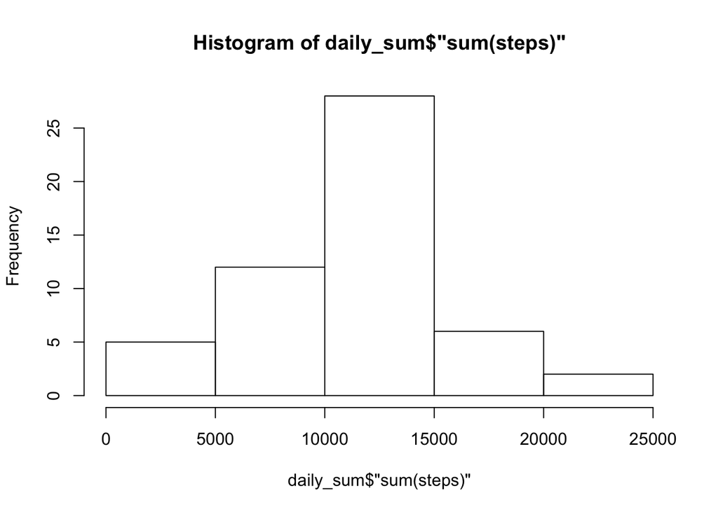

```r
hist(daily_sum$"sum(steps)")
```

3. Calculate and report the mean and median of the total number of steps taken per day

```r
daily_mean <- summarize(group_by(activity, date), mean(steps))
daily_median <- summarize(group_by(activity, date), median(steps))
daily_mean
```

```
## Source: local data frame [61 x 2]
##
##          date mean(steps)
## 1  2012-10-01          NA
## 2  2012-10-02     0.43750
## 3  2012-10-03    39.41667
## 4  2012-10-04    42.06944
## 5  2012-10-05    46.15972
## 6  2012-10-06    53.54167
## 7  2012-10-07    38.24653
## 8  2012-10-08          NA
## 9  2012-10-09    44.48264
## 10 2012-10-10    34.37500
## ..        ...         ...
```

```r
daily_median
```

```
## Source: local data frame [61 x 2]
##
##          date median(steps)
## 1  2012-10-01            NA
## 2  2012-10-02             0
## 3  2012-10-03             0
## 4  2012-10-04             0
## 5  2012-10-05             0
## 6  2012-10-06             0
## 7  2012-10-07             0
## 8  2012-10-08            NA
## 9  2012-10-09             0
## 10 2012-10-10             0
## ..        ...           ...
```

## What is the average daily activity pattern?

1. Make a time series plot (i.e. type = “l” ) of the 5-minute interval (x-axis) and the average number of steps taken, averaged across all days (y-axis)

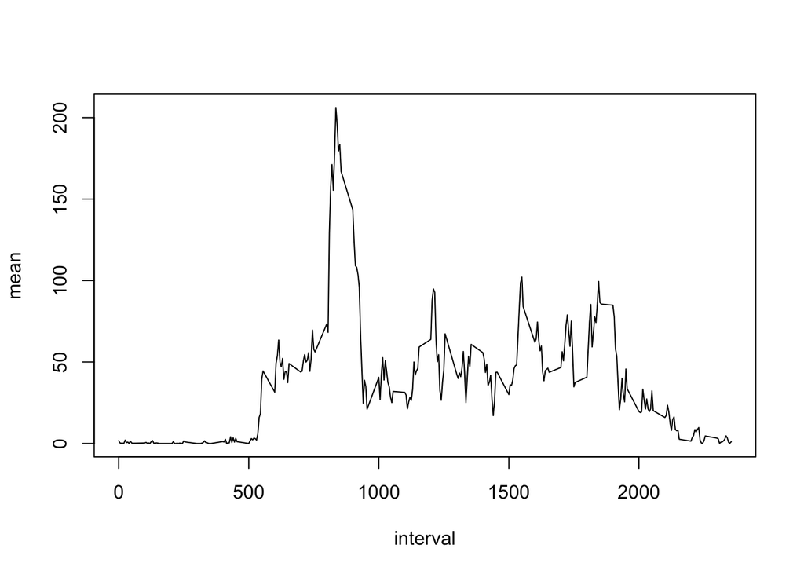

```r
average_daily <- summarize(group_by(activity, interval), mean(steps,na.rm=TRUE))
      colnames(average_daily) <- c("interval", "mean")
      plot(average_daily,type="l")
```

2. Which 5-minute interval, on average across all the days in the dataset, contains the maximum number of steps?

```r
max_index <- which.max(average_daily$mean)
average_daily$interval[max_index]
```

```
## [1] 835
```

## Imputing missing values

1. Calculate and report the total number of missing values in the dataset (i.e. the total number of rows with NA s)

```r
NA_sum <-  sum(is.na(activity$steps))
NA_sum
```

```
## [1] 2304
```

2. Devise a strategy for filling in all of the missing values in the dataset. The strategy does not need to be sophisticated. For example, you could use the mean/median for that day, or the mean for that 5-minute interval, etc.

The Strategy I have chosen is to replace the missing values with the mean for that 5-minute internval

3. Create a new dataset that is equal to the original dataset but with the missing data filled in.

```r
new_activity <- activity
row_count <- dim(new_activity)[1]

      for(i in 1:row_count){
            if(is.na(new_activity$steps[i])) {
                  missing_interval <- new_activity$interval[i]
                  imputted_missing <- average_daily[which(average_daily$interval==missing_interval), ]$mean
                  new_activity$steps[i] <- imputted_missing
                  }
      }
```

4. Make a histogram of the total number of steps taken each day.

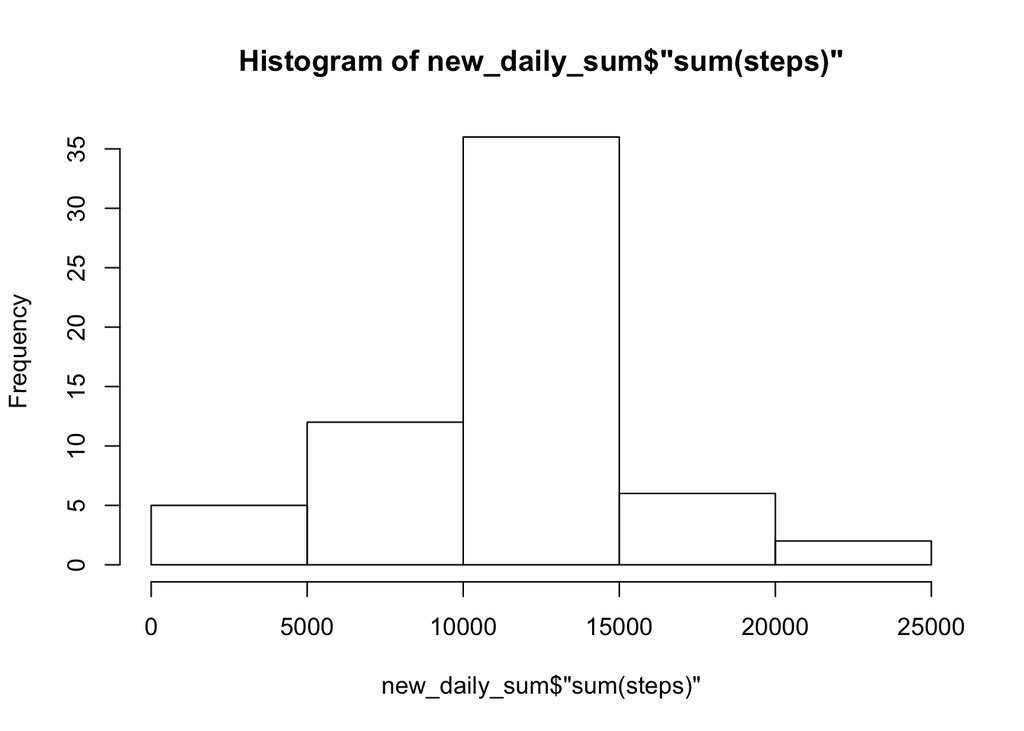

```r
new_daily_sum <- summarize(group_by(new_activity, date), sum(steps))
hist(new_daily_sum$"sum(steps)")
```

Calculate and report the mean and median total number of steps taken per day.

```r
new_daily_mean <- summarize(group_by(activity, date), mean(steps))
new_daily_median <- summarize(group_by(activity, date), median(steps))
new_daily_mean
```

```
## Source: local data frame [61 x 2]
##
##          date mean(steps)
## 1  2012-10-01          NA
## 2  2012-10-02     0.43750
## 3  2012-10-03    39.41667
## 4  2012-10-04    42.06944
## 5  2012-10-05    46.15972
## 6  2012-10-06    53.54167
## 7  2012-10-07    38.24653
## 8  2012-10-08          NA
## 9  2012-10-09    44.48264
## 10 2012-10-10    34.37500
## ..        ...         ...
```

```r
new_daily_median
```

```
## Source: local data frame [61 x 2]
##
##          date median(steps)
## 1  2012-10-01            NA
## 2  2012-10-02             0
## 3  2012-10-03             0
## 4  2012-10-04             0
## 5  2012-10-05             0
## 6  2012-10-06             0
## 7  2012-10-07             0
## 8  2012-10-08            NA
## 9  2012-10-09             0
## 10 2012-10-10             0
## ..        ...           ...
```

## Are there differences in activity patterns between weekdays and weekends?

1. Create a new factor variable in the dataset with two levels – “weekday” and “weekend” indicating whether a given date is a weekday or weekend day.

```r
activity$date <- as.Date(as.character(activity$date), "%Y-%m-%d")
weekdays <- weekdays(activity$date)
weekdays <- plyr::mapvalues(weekdays, c("Monday", "Tuesday", "Wednesday", "Thursday", "Friday", "Saturday", "Sunday"), c("Weekday", "Weekday","Weekday", "Weekday","Weekday", "Weekend", "Weekend"))
new_activity <- cbind(new_activity,weekdays)
```

2. Make a panel plot containing a time series plot (i.e. type = “l” ) of the 5-minute interval (x-axis) and the average number of steps taken, averaged across all weekday days or weekend days (y-axis).

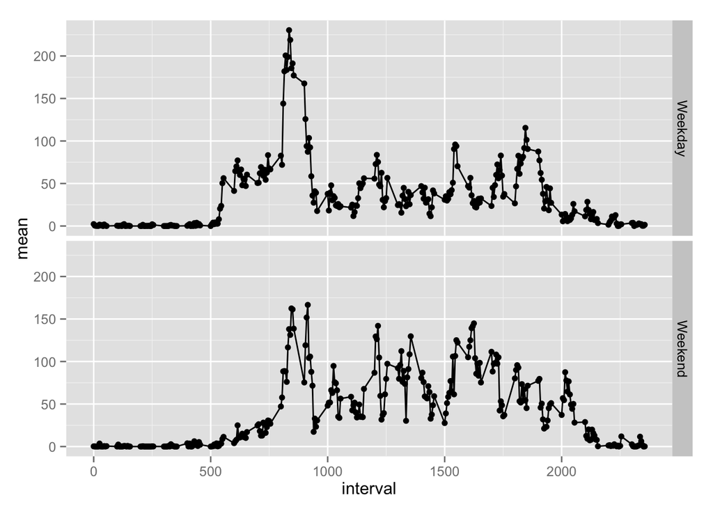

```r
library("ggplot2")
new_average_daily <- summarize(group_by(new_activity, weekdays, interval), mean(steps,na.rm=TRUE))
colnames(new_average_daily) <- c("weekdays", "interval", "mean")

g <- qplot(interval, mean, data=new_average_daily, facets= weekdays~.)
g + geom_line()
```